# Tres en raya - Clasificación naive bayes

- **Víctor Bucheli Guerrero**
- **Universidad del Valle**
- **Mayo 31 / 2018**

# Tic-Tac-Toe Endgame database

**Información relevante al dataset:**

Esta base de datos codifica el conjunto completo de posibles configuraciones de placa al final de los juegos de tres en raya, donde se supone que jugó “x” primero. El concepto objetivo es “ganar para x” (es decir, positiva cuando “x” tiene uno de 8 maneras posibles de crear un “tres en raya”).

Número de instancias: 958 (tableros legales de final de tres en raya)

Número de atributos: 9, cada uno correspondiente a un cuadrado de tres en raya

Informacion de los atributos: (x=player x has taken, o=player o has taken, b=blank)

```
1. top-left-square: {x,o,b}
2. top-middle-square: {x,o,b}
3. top-right-square: {x,o,b}
4. middle-left-square: {x,o,b}
5. middle-middle-square: {x,o,b}
6. middle-right-square: {x,o,b}
7. bottom-left-square: {x,o,b}
8. bottom-middle-square: {x,o,b}
9. bottom-right-square: {x,o,b}
10. Class: {1,0}
```

## Carga de datos

```r
#Cargamos el dataset
tictactoe.dataset = read.csv("tictactoe.csv")
# Asignamos los nombres de las columnas
colnames(tictactoe.dataset) <- c("tls","tms","trs","mls", "mms", "mrs", "bls", "bms", "brs", "clase")
#volvemos categorico la columna "clase"
tictactoe.dataset[, "clase"] <-as.factor(tictactoe.dataset[, "clase"])
```

## Partir los datos en el conjunto de entrenamiento y de pruebas

Para el conjunto de entrenamiento se va a extraer el 70% de los datos de tictactoe.dataset, el otro 30% se va a usar para el conjunto de pruebas, se inicializa en la misma semilla para hacer el experimento reproducible.

```r
set.seed(1234) # semilla
muestra.cantidad <- floor(0.7 * nrow(tictactoe.dataset)) #Obtenemos el tamaño del conjunto de entrenamiento
entrenamiento.index <- sample(seq_len(nrow(tictactoe.dataset)), size = muestra.cantidad) #Obtenemos los index de los datos que van a servir de enttenamiento
conjunto_entrenamiento <- tictactoe.dataset[entrenamiento.index, ] #Conjunto de entrenamiento
conjunto_prueba <- tictactoe.dataset[- entrenamiento.index, ] #Conjunto de Prueba, toma los index que no son de entrenamaiento
```

## Entrenamiento

Para utilizar el algoritmo Naive Bayes utilizamos la función predeterminada que viene en la librería e1071. Para este caso concreto vamos a utilizar la función naiveBayes ingresando la formula y el conjunto del cual se entrenará el modelo. La formula viene dada de la siguiente forma

### *C<sub>1</sub> ~ X<sub>1</sub> + X<sub>2</sub> + … + X<sub>n</sub>*

Donde *C<sub>1</sub>* es la clase y *X<sub>i</sub>* son los atributos que nos ayudarán a determinar la clase.

```r
#install.packages("e1071", dep = TRUE)
library(e1071)
formula <- clase ~ tls + tms + trs + mls + mms + mrs + bls + bms + brs
modelo <- naiveBayes(formula, data = conjunto_entrenamiento)
modelo
```

```
Naive Bayes Classifier for Discrete Predictors

Call:
naiveBayes.default(x = X, y = Y, laplace = laplace)

A-priori probabilities:
Y
        0         1
0.3363229 0.6636771

Conditional probabilities:
   tls
Y           b         o         x
  0 0.1777778 0.4755556 0.3466667
  1 0.2207207 0.3153153 0.4639640

   tms
Y           b         o         x
  0 0.2222222 0.3155556 0.4622222
  1 0.2905405 0.3490991 0.3603604

   trs
Y           b         o         x
  0 0.1955556 0.4133333 0.3911111
  1 0.2252252 0.3153153 0.4594595

   mls
Y           b         o         x
  0 0.2355556 0.2800000 0.4844444
  1 0.2837838 0.3648649 0.3513514

   mms
Y           b         o         x
  0 0.1333333 0.5866667 0.2800000
  1 0.1599099 0.2274775 0.6126126

   mrs
Y           b         o         x
  0 0.2711111 0.2666667 0.4622222
  1 0.2702703 0.3783784 0.3513514

   bls
Y           b         o         x
  0 0.1866667 0.4533333 0.3600000
  1 0.2297297 0.2950450 0.4752252

   bms
Y           b         o         x
  0 0.2444444 0.3200000 0.4355556
  1 0.2590090 0.3648649 0.3761261

   brs
Y           b         o         x
  0 0.2088889 0.4266667 0.3644444
  1 0.2274775 0.3063063 0.4662162
```

```r
prediccion <- predict(modelo,conjunto_prueba)
prediccion
```

```
  [1] 1 0 0 0 1 1 1 1 0 0 1 1 1 1 1 1 1 1 1 1 1 0 0 0 1 0 1 1 1 0 1 1 1 1 0 1 0 1 1 1 1 1 1 1 1 1 1 1 1 1 1 1 1 1 1 1
 [57] 1 1 1 1 1 1 1 1 1 1 1 1 1 1 1 1 1 1 1 1 1 1 1 1 1 1 0 1 1 1 1 1 1 1 1 1 1 0 0 0 1 0 0 1 1 0 0 1 0 1 1 1 1 0 0 1
[113] 1 1 0 1 1 1 1 1 1 1 1 1 1 1 1 1 1 1 1 1 0 1 0 1 1 1 0 1 1 1 1 1 1 1 1 1 1 0 1 1 1 1 1 1 1 1 1 1 1 1 1 1 1 1 1 1
[169] 1 1 1 1 1 1 1 1 1 1 1 1 1 1 0 0 1 1 0 1 0 0 0 0 1 0 1 1 1 1 1 1 0 1 1 1 1 1 1 0 0 1 1 1 1 1 1 1 1 0 1 0 1 1 1 0
[225] 0 1 1 1 1 0 1 0 0 0 1 1 1 1 0 0 1 1 1 1 1 0 0 1 0 1 1 0 0 0 0 1 0 0 1 0 1 1 1 1 1 0 0 0 0 0 1 0 1 0 1 1 1 0 1 1
[281] 1 1 1 1 1 1 0 0
Levels: 0 1
```

## Pruebas

Ahora creemos la matriz de confusión probando el modelo con el conjunto de pruebas y saquemos algunas conclusiones:

```r
testPred_tictactoe_naiveBayes <- predict(modelo, newdata = conjunto_prueba)
table(testPred_tictactoe_naiveBayes, conjunto_prueba[, "clase"])
```

```
testPred_tictactoe_naiveBayes   0   1
                            0  41  28
                            1  66 153
```

[output not shown]

## Desempeño con curva de ROC

La curva de ROC nos proporciona una medida de desempeño de nuestro clasificador, entre mas cercana el area bajo la curva de ROC sea a 1, mejor es nuestro clasificador.

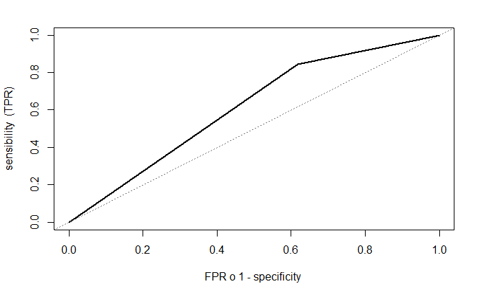

```r
#install.packages("ROCR", dep = TRUE)
library(ROCR)
roc_pred <- prediction(as.numeric(testPred_tictactoe_naiveBayes), as.numeric(conjunto_prueba[, "clase"]))
perf <-performance(roc_pred, measure="tpr", x.measure="fpr")
plot(perf, lwd=2, xlab="FPR o 1 - specificity ",
 ylab="sensibility  (TPR)")
abline(a=0, b=1, col="gray50", lty=3) #Dibujamos la diagonal
```

## AUC - Area bajo la curva ROC

```r
auc <- performance(roc_pred, "auc")
auc <- unlist(slot(auc, "y.values"))
auc
```

```
[1] 0.6142407
```